# Proximity sensor testing Nov 10

We ran a test to compare the performance of dulog and proxlog tags under standardized conditions. In each test, we placed 5 tags on a grid with “North”, “South”, “East”, “West”, and “Center” as their positions. In the first test “ten-parallel”, each tag on a cardinal direction was 10cm from the central tag, with all the tags facing in roughly the same orientation (“parallel”), and kept for about 10 minutes. Later tests (50, 100, 200…) the tags were moved 50 cm from the center, and so on. For the 10-100 distances, we also ran tests where we rotated the tags so that they faced in haphazard directions (“moved” tests) Write abstract with Summary From the ground up thing in the beginning Here is the beginning, and here are the results

- variation across tags at a given distance in signal - calc standard deviation by group, plot sd - test for significant differences between groups @ given distance? (groupby distance/ whatever sd comparison test bt tag) - to compare variance between groups: levene test, brown-forsythe test, Bartlett’s test (more powerful) - try standarizing the values? subtract or add from each?

  ```
  - percent variance? (look at difs in means?)
  ```

- signal strength with distance across different tags
- compare sensitivity to tag direction across the different tags different in signal strength or not? what % weaker
- Differences within each group?
- % pr probability is useful as a statistic ()
- battery performance
- saline glove and flight cage conditions

```r
library(tidyverse)
library(readr)
library(lubridate)
```

Goals: 1. see the number of reads from each tag 2. tag each meeting by pairwise distance — convert times into datetimes? — if datetime between X and X, joinby?  
3. compare rssi by distance

```r
#test_table <- read.csv("https://raw.githubusercontent.com/maydixon/proximity-sensors/main/test_table.csv", sep=",", header=TRUE ) #stringsAsFactors = F

test_table <- read_csv("test_table_nov10.csv")
# MN_DATA_nov7_2 <- read.csv("https://raw.githubusercontent.com/maydixon/proximity-sensors/blob/main/23-11-08/15-51-42/MN_DATA.CSV",sep=",", header=TRUE, stringsAsFactors = F )
# for some reason reading in with a lagging line

DU_DATA <- read_csv("dulog/23-11-10/17-00-24/MN_DATA_17-00-24.CSV")
DU_DATA <- DU_DATA %>%
      mutate(tag = "dulog")

 #remove spaces from DU_DATA column names
colnames(DU_DATA) <- sub(" ", "_", colnames(DU_DATA))



#for some obnoxious reason, L3 and L4 read in with col names automatically with read_CSV, and the others don't


# import proxlog data- take all the files in a folder and pull them into the same dataframe
PR_DATA <- list.files(path = "proxlog real test/",  # Identify all CSV files with L in the name
                       pattern = "L", full.names = TRUE) %>% #
  lapply(read.csv, col.names = c("RX_Node","TX_Node","Date_Time", "RSSI")) %>%                              # Store all files in list
  bind_rows         %>%                     # Combine data sets into one data set
  mutate(tag = "proxlog") #add proxlog to all rows

### not needed anymore

# L1<- read.csv("proxlog real test/L1.CSV", col.names=c("RX_Node","TX_Node","Date_Time", "RSSI"), fill=TRUE, header=TRUE)
# L2<- read.csv("proxlog real test/L2.CSV")
# L3<- read.csv("proxlog real test/L3.CSV", col.names = c("RX_Node","TX_Node","Date_Time", "RSSI"))
# L4<- read.csv("proxlog real test/L4.CSV", col.names = c("RX_Node","TX_Node","Date_Time", "RSSI"))
# L5<- read_csv("proxlog real test/L5.CSV")
# P_list<- list(L1, L2, L3, L4, L5)
# lapply(P_list, View)




str(PR_DATA)
```

```
'data.frame':   29610 obs. of  5 variables:
 $ RX_Node  : int  1 1 1 1 1 1 1 1 1 1 ...
 $ TX_Node  : int  5 3 4 2 3 5 4 2 3 5 ...
 $ Date_Time: chr  " 10/11/2023 21:45:11 GPS" " 10/11/2023 21:45:11 GPS" " 10/11/2023 21:45:13 GPS" " 10/11/2023 21:45:13 GPS" ...
 $ RSSI     : int  -61 -66 -67 -71 -66 -63 -67 -71 -66 -61 ...
 $ tag      : chr  "proxlog" "proxlog" "proxlog" "proxlog" ...
```

FIX Dulog date/time

```r
#put date time in one column for DU_DATA
DU_DATA <- DU_DATA %>%
       mutate(Date_Time = make_datetime(year = Meeting_Year, month = Meeting_Month, day = Meeting_Day, hour = Meeting_Hour,min =  Meeting_Minute, sec = Meeting_Second, tz="America/New_York")) #Etc/GMT-5
head(DU_DATA$Date_Time)
```

```
[1] "2023-11-10 12:24:28 EST" "2023-11-10 12:24:30 EST" "2023-11-10 12:24:34 EST" "2023-11-10 12:24:36 EST"
[5] "2023-11-10 12:24:38 EST" "2023-11-10 12:24:42 EST"
```

fix test table date/time, add timezone

```r
# put date time in one column for reference table
test_table <- test_table %>%
      mutate(start_time = make_datetime(year = start_year, month = start_month, day = start_day, hour = start_hour, min =  start_minute, sec = start_second),
             end_time = make_datetime(year = end_year, month = end_month, day = end_day, hour = end_hour, min =  end_minute, sec = end_second))
str(test_table)
```

```
tibble [210 × 23] (S3: tbl_df/tbl/data.frame)
 $ tag           : chr [1:210] "dulog" "dulog" "dulog" "dulog" ...
 $ test          : chr [1:210] "ten" "ten" "ten" "ten" ...
 $ type_parallel : chr [1:210] "parallel" "parallel" "parallel" "parallel" ...
 $ tag_A         : num [1:210] 69 69 69 69 42 42 42 73 73 35 ...
 $ TagA_position : chr [1:210] "N" "N" "N" "N" ...
 $ tag_B         : num [1:210] 42 73 35 86 73 35 86 35 86 86 ...
 $ Tag_B_position: chr [1:210] "W" "E" "S" "C" ...
 $ distance_cm   : num [1:210] 14.1 14.1 20 10 20 ...
 $ start_year    : num [1:210] 2023 2023 2023 2023 2023 ...
 $ start_month   : num [1:210] 11 11 11 11 11 11 11 11 11 11 ...
 $ start_day     : num [1:210] 10 10 10 10 10 10 10 10 10 10 ...
 $ start_hour    : num [1:210] 12 12 12 12 12 12 12 12 12 12 ...
 $ start_minute  : num [1:210] 29 29 29 29 29 29 29 29 29 29 ...
 $ start_second  : num [1:210] 0 0 0 0 0 0 0 0 0 0 ...
 $ end_year      : num [1:210] 2023 2023 2023 2023 2023 ...
 $ end_month     : num [1:210] 11 11 11 11 11 11 11 11 11 11 ...
 $ end_day       : num [1:210] 10 10 10 10 10 10 10 10 10 10 ...
 $ end_hour      : num [1:210] 12 12 12 12 12 12 12 12 12 12 ...
 $ end_minute    : num [1:210] 39 39 39 39 39 39 39 39 39 39 ...
 $ end_second    : num [1:210] 0 0 0 0 0 0 0 0 0 0 ...
 $ base_ID       : logi [1:210] NA NA NA NA NA NA ...
 $ start_time    : POSIXct[1:210], format: "2023-11-10 12:29:00" "2023-11-10 12:29:00" "2023-11-10 12:29:00" ...
 $ end_time      : POSIXct[1:210], format: "2023-11-10 12:39:00" "2023-11-10 12:39:00" "2023-11-10 12:39:00" ...
```

```r
#Force into same timezone
test_table$start_time <-  force_tz(test_table$start_time, tzone = "America/New_York")

head(test_table$start_time)
```

```
[1] "2023-11-10 12:29:00 EST" "2023-11-10 12:29:00 EST" "2023-11-10 12:29:00 EST" "2023-11-10 12:29:00 EST"
[5] "2023-11-10 12:29:00 EST" "2023-11-10 12:29:00 EST"
```

```r
class(test_table$start_time)
```

```
[1] "POSIXct" "POSIXt"
```

correct data and time for PR_DATA convert to POSIX change to same time format as other dataset

```r
#convert character to date time format of data (tz is the default GMT timezone the tags record in)
PR_DATA$Date_Time <-  as.POSIXlt(PR_DATA$Date_Time, format ="%d/%m/%Y %H:%M:%S", tz= "Etc/GMT" )
head(PR_DATA$Date_Time)
```

```
[1] "2023-11-10 21:45:11 GMT" "2023-11-10 21:45:11 GMT" "2023-11-10 21:45:13 GMT" "2023-11-10 21:45:13 GMT"
[5] "2023-11-10 21:45:13 GMT" "2023-11-10 21:45:13 GMT"
```

```r
#change to real time zone
PR_DATA$Date_Time<- with_tz(PR_DATA$Date_Time, tzone = "America/New_York")
head(PR_DATA$Date_Time)
```

```
[1] "2023-11-10 16:45:11 EST" "2023-11-10 16:45:11 EST" "2023-11-10 16:45:13 EST" "2023-11-10 16:45:13 EST"
[5] "2023-11-10 16:45:13 EST" "2023-11-10 16:45:13 EST"
```

```r
head(PR_DATA)
```

|  | RX_Node | TX_Node | Date_Time | RSSI | tag |
| --- | --- | --- | --- | --- | --- |
| 1 | 1 | 5 |  | -61 | proxlog |
| 2 | 1 | 3 |  | -66 | proxlog |
| 3 | 1 | 4 |  | -67 | proxlog |
| 4 | 1 | 2 |  | -71 | proxlog |
| 5 | 1 | 3 |  | -66 | proxlog |
| 6 | 1 | 5 |  | -63 | proxlog |

combine Proxlog and and Dulog datasets

```r
#for now dropping all the receiving ID/ download time columns from Dulog, could keep with rbind fill = TRUE
Tag_Data <- DU_DATA %>%
      select(RX_Node, TX_Node, Date_Time, RSSI, tag ) %>%
      rbind(PR_DATA)
head(Tag_Data$Date_Time)
```

```
[1] "2023-11-10 12:24:28 EST" "2023-11-10 12:24:30 EST" "2023-11-10 12:24:34 EST" "2023-11-10 12:24:36 EST"
[5] "2023-11-10 12:24:38 EST" "2023-11-10 12:24:42 EST"
```

add p or d to tag along with NSEWC for test table

```r
# Make tag names indicate tag type (d or p), then position (SNEWC), then unique ID e.g. "69"
#if rerunning run from top
test_table <- test_table %>%
      mutate(RX_Node = paste(TagA_position, tag_A,  sep = ""),
             TX_Node = paste(Tag_B_position, tag_B, sep = "")) %>%
      mutate_at( c("RX_Node", "TX_Node"), funs(ifelse(tag=="dulog", paste("d", ., sep=""), paste("p", ., sep=""))))
```

Add positions and tag labels to Tag_Data (N, S E W to tag titles)

```r
# add cardinal position to each tag type and tag brand
Tag_Data <- Tag_Data %>%
      mutate_at(vars("RX_Node","TX_Node"), ~ as.character(.)) %>%
     mutate_at(vars("RX_Node","TX_Node"), ~ case_when( . == "1"|. == "69" ~ paste("N", ., sep = ""), # add position to all tags
                                                       . == "2" |. == "42"~ paste("W", ., sep = ""),
                                                       . == "3" |. == "73"~ paste("E", ., sep = ""),
                                                       . == "4" |. == "35"~ paste("S", ., sep = ""),
                                                       . == "5" |. == "86"~ paste("C", ., sep = ""),
                                                      TRUE ~ . #keep any original values that were not changed
                                                      )
              ) %>%
       mutate_at( vars("RX_Node", "TX_Node"), ~ ifelse(tag=="dulog", paste("d", ., sep=""), paste("p", ., sep=""))) #add tag brand to each tag id





#come back later to figure out why each group only has 4 tags!
```

#come back later to figure out why each group only has 4 tags!

Combine sender and receiver in all docs, make directionless

```r
head(Tag_Data)
```

| RX_Node | TX_Node | Date_Time | RSSI | tag |
| --- | --- | --- | --- | --- |
| dE73 | dW42 | 2023-11-10 12:24:28 | -64 | dulog |
| dE73 | dW42 | 2023-11-10 12:24:30 | -64 | dulog |
| dE73 | dW42 | 2023-11-10 12:24:34 | -64 | dulog |
| dE73 | dW42 | 2023-11-10 12:24:36 | -64 | dulog |
| dE73 | dW42 | 2023-11-10 12:24:38 | -64 | dulog |
| dE73 | dW42 | 2023-11-10 12:24:42 | -58 | dulog |

```r
#make combined receiver sender column RX_TX, and directionless dyad column
Tag_Data <- Tag_Data %>%
      mutate( RX_TX = paste(RX_Node, TX_Node, sep = "_")) %>% #receiver/ sender
      mutate(Dyad = ifelse(RX_Node < TX_Node, RX_TX, paste(TX_Node, RX_Node, sep = "_"))  ) # directionless dyad

#same for test table
test_table <- test_table %>%
      mutate( RX_TX = paste(RX_Node, TX_Node, sep = "_")) %>%
      mutate(Dyad = ifelse(RX_Node < TX_Node, RX_TX, paste(TX_Node, RX_Node, sep = "_"))  )


#make separate columns for test distance and tag orientation
test_table <- test_table %>%
      mutate( test_type = paste(test, type_parallel, sep = "_"))
```

Add trial types to Tag_Data by time range

```r
#show each of the time values
test_table %>%
      select(tag, test_type, start_time, end_time) %>%
      group_by(tag, test_type)%>%
      filter(row_number()==1) %>% filter(tag== "dulog")
```

| tag | test_type | start_time | end_time |
| --- | --- | --- | --- |
| dulog | ten_parallel | 2023-11-10 12:29:00 | 2023-11-10 12:39:00 |
| dulog | ten_moved | 2023-11-10 12:42:00 | 2023-11-10 12:52:00 |
| dulog | fifty_parallel | 2023-11-10 12:54:00 | 2023-11-10 13:04:00 |
| dulog | fifty_moved | 2023-11-10 13:06:00 | 2023-11-10 13:16:00 |
| dulog | hundred_parallel | 2023-11-10 13:18:00 | 2023-11-10 13:28:00 |
| dulog | hundred_moved | 2023-11-10 13:30:00 | 2023-11-10 13:40:00 |
| dulog | twohundred_parallel | 2023-11-10 13:46:00 | 2023-11-10 13:50:00 |
| dulog | threehundred_parallel | 2023-11-10 13:52:00 | 2023-11-10 13:56:00 |
| dulog | fourhundred_parallel | 2023-11-10 13:57:00 | 2023-11-10 14:04:00 |
| dulog | fivehundred_parallel | 2023-11-10 14:07:00 | 2023-11-10 14:09:00 |

[output cut: 1 more lines]

```r
Tag_Data <- Tag_Data %>%
      mutate(test_type = case_when(
Date_Time >= as.POSIXct("2023-11-10 12:29:00", tz = "America/New_York") & Date_Time <= as.POSIXct("2023-11-10 12:39:00", tz = "America/New_York") ~ "ten_parallel",
Date_Time >= as.POSIXct("2023-11-10 12:42:00    ", tz = "America/New_York") & Date_Time <= as.POSIXct("2023-11-10 12:52:00", tz = "America/New_York") ~ "ten_moved",
Date_Time >= as.POSIXct("2023-11-10 12:54:00", tz = "America/New_York") & Date_Time <= as.POSIXct("2023-11-10 13:04:00", tz = "America/New_York") ~ "fifty_parallel",
Date_Time >= as.POSIXct("2023-11-10 13:06:00", tz = "America/New_York") & Date_Time <= as.POSIXct("2023-11-10 13:16:00", tz = "America/New_York") ~ "fifty_moved",
Date_Time >= as.POSIXct("2023-11-10 13:18:00", tz = "America/New_York") & Date_Time <= as.POSIXct("2023-11-10 13:28:00", tz = "America/New_York") ~ "hundred_parallel",
Date_Time >= as.POSIXct("2023-11-10 13:30:00", tz = "America/New_York") & Date_Time <= as.POSIXct("2023-11-10 13:40:00", tz = "America/New_York") ~ "hundred_moved",
Date_Time >= as.POSIXct("2023-11-10 16:36:00", tz = "America/New_York") & Date_Time <= as.POSIXct("2023-11-10 16:46:00", tz = "America/New_York") ~ "ten_parallel",
Date_Time >= as.POSIXct("2023-11-10 16:51:00    ", tz = "America/New_York") & Date_Time <= as.POSIXct("2023-11-10 17:01:00", tz = "America/New_York") ~ "ten_moved",
Date_Time >= as.POSIXct("2023-11-10 17:03:00", tz = "America/New_York") & Date_Time <= as.POSIXct("2023-11-10 17:13:00", tz = "America/New_York") ~ "fifty_parallel",
Date_Time >= as.POSIXct("2023-11-10 17:15:00", tz = "America/New_York") & Date_Time <= as.POSIXct("2023-11-10 17:25:00", tz = "America/New_York") ~ "fifty_moved",
Date_Time >= as.POSIXct("2023-11-10 17:27:00", tz = "America/New_York") & Date_Time <= as.POSIXct("2023-11-10 17:37:00", tz = "America/New_York") ~ "hundred_parallel",
Date_Time >= as.POSIXct("2023-11-10 17:39:00", tz = "America/New_York") & Date_Time <= as.POSIXct("2023-11-10 17:49:00", tz = "America/New_York") ~ "hundred_moved",
Date_Time >= as.POSIXct("2023-11-10 17:51:00", tz = "America/New_York") & Date_Time <= as.POSIXct("2023-11-10 17:56:00", tz = "America/New_York") ~ "twohundred_parallel",
Date_Time >= as.POSIXct("2023-11-10 17:57:00", tz = "America/New_York") & Date_Time <= as.POSIXct("2023-11-10 17:59:00", tz = "America/New_York") ~ "threehundred_parallel",
Date_Time >= as.POSIXct("2023-11-10 18:03:00", tz = "America/New_York") & Date_Time <= as.POSIXct("2023-11-10 18:05:00", tz = "America/New_York") ~ "fourhundred_parallel",
Date_Time >= as.POSIXct("2023-11-10 18:08:00", tz = "America/New_York") & Date_Time <= as.POSIXct("2023-11-10 18:10:00", tz = "America/New_York") ~ "fivehundred_parallel",
Date_Time >= as.POSIXct("2023-11-10 13:46:00", tz = "America/New_York") & Date_Time <= as.POSIXct("2023-11-10 13:50:00", tz = "America/New_York") ~ "twohundred_parallel",
Date_Time >= as.POSIXct("2023-11-10 13:52:00", tz = "America/New_York") & Date_Time <= as.POSIXct("2023-11-10 13:56:00", tz = "America/New_York") ~ "threehundred_parallel",
Date_Time >= as.POSIXct("2023-11-10 13:57:00", tz = "America/New_York") & Date_Time <= as.POSIXct("2023-11-10 14:04:00", tz = "America/New_York") ~ "fourhundred_parallel",
Date_Time >= as.POSIXct("2023-11-10 14:07:00    ", tz = "America/New_York") & Date_Time <= as.POSIXct("2023-11-10 14:09:00", tz = "America/New_York") ~ "fivehundred_parallel",
Date_Time >= as.POSIXct("2023-11-10 14:12:00", tz = "America/New_York") & Date_Time <= as.POSIXct("2023-11-10 14:15:00", tz = "America/New_York") ~ "sixhundred_parallel",
.default = "group_no"
))
```

join reference test-table with known distances and Tag_Data make a dummy variable with unique trial and dyad, match with that

```r
# make dummy variables for joining test_table and Tag_Data
test_table <- test_table %>%
      mutate( Dyad_test_type = paste(Dyad, test_type, sep = "_"))

Tag_Data <- Tag_Data %>%
      mutate( Dyad_test_type = paste(Dyad, test_type, sep = "_"))

#add the test_table values to the data
Tag_Data$distance_cm <- test_table$distance_cm[match(Tag_Data$Dyad_test_type, test_table$Dyad_test_type)]

#separate test_type, copy column
Tag_Data <- Tag_Data %>%
      mutate(test_type1 = test_type)  %>%
     separate(test_type1, c('test', 'type_parallel'))


#also, make tags ordered factors
Tag_Data <- Tag_Data %>%
      mutate_at(vars(RX_Node, TX_Node), ~  factor(., ordered = TRUE))
```

## Data analysis

Meetings recorded by receiving tags by time - Looking at only the day we recorded (Nov 10)

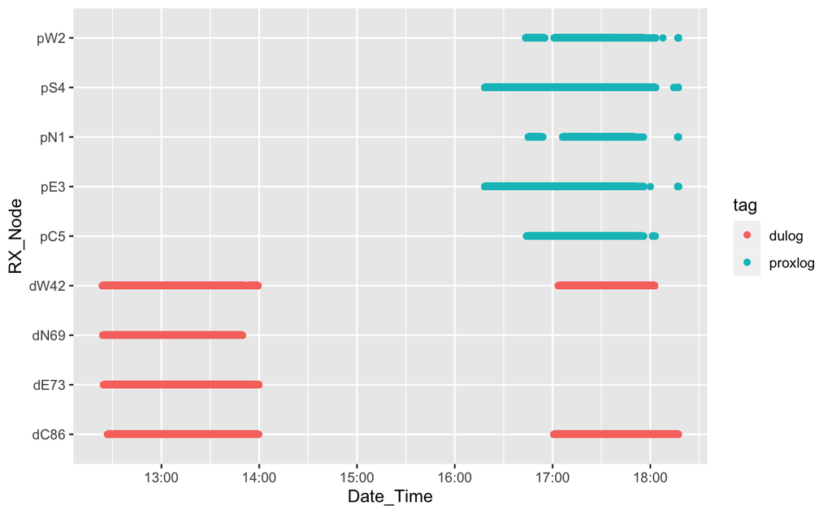

```r
  # a lot of data from the 7th, also a random one from the 20th

#select only the date we are looking at (the 10th)
#reorder so that the tag types are next to one another
Tag_Data %>%
     filter(Date_Time > as.POSIXct('2023-11-10 00:00:01', tz= "ETC")) %>%
       filter(Date_Time < as.POSIXct('2023-11-10 23:59:59', tz= "ETC")) %>%
      ggplot( aes(y=RX_Node, x= Date_Time, color= tag)) +
      geom_point()
```

While Dulog did download data from a previous day, which is normal, it also made up some weird date-times. (tag 42 had a read from the next year a,and a month previously

Its also strange that only 2 of the dulogs recorded in the evening, when i downloaded the data, as they were all on and right next to each other.

Meetings recorded by transmitting tags by time

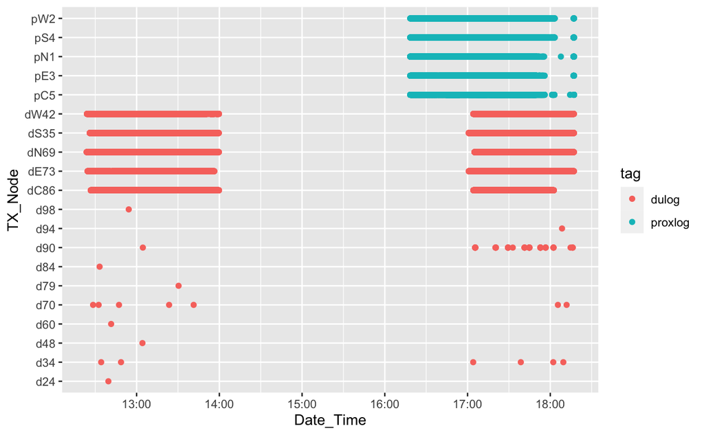

```r
Tag_Data %>%
     filter(Date_Time > as.POSIXct('2023-11-10 00:00:01', tz= "ETC")) %>%
       filter(Date_Time < as.POSIXct('2023-11-10 23:59:59', tz= "ETC")) %>%
      ggplot( aes(y=TX_Node, x= Date_Time, color= tag)) +
      geom_point()
```

```r
#so at this point the dulog tags did not download after 1pm
```

Dulog also made up a bunch of fake transmitting tags at weird times

Include only data from the 10th in subsequent analyses

```r
Tag_Data  <- Tag_Data %>%
     filter(Date_Time > as.POSIXct('2023-11-10 00:00:01', tz= "ETC")) %>%
       filter(Date_Time < as.POSIXct('2023-11-10 23:59:59', tz= "ETC"))
```

```r
Tag_Data <- Tag_Data %>% filter((tag != "dulog") | (tag == "dulog" & Date_Time < as.POSIXct('2023-11-10 14:30:00'))) %>% #keep all rows where tag is not dulog or time later than 2:30.
      filter(test_type!= "group_no")

#show the new max and min times for each tag
Tag_Data %>% group_by(tag) %>% summarize(n=n(), max = max(Date_Time), min= min(Date_Time))
```

| tag | n | max | min |
| --- | --- | --- | --- |
| dulog | 30301 | 2023-11-10 13:59:46 | 2023-11-10 12:29:00 |
| proxlog | 20682 | 2023-11-10 18:03:16 | 2023-11-10 16:36:00 |

```r
NA
```

This shows that the tags didn’t download anything after 2pm. Probably bc nothing after the hour downloaded (though we gave them an opportunity to later, but possibly bc these were mostly the 5 and 6m from center tests)

Total number of reads transmitted and received by each individual tag

```r
#number of meetings transmitted and received by each tag
Tag_Data %>%
      group_by(tag, TX_Node) %>%
      summarise(n=n())
```

| tag | TX_Node | n |
| --- | --- | --- |
| dulog | d34 | 2 |
| dulog | d70 | 3 |
| dulog | d79 | 1 |
| dulog | d84 | 1 |
| dulog | d98 | 1 |
| dulog | dC86 | 5790 |
| dulog | dE73 | 5437 |
| dulog | dN69 | 5833 |
| dulog | dS35 | 7666 |
| dulog | dW42 | 5567 |

[output cut: 5 more lines]

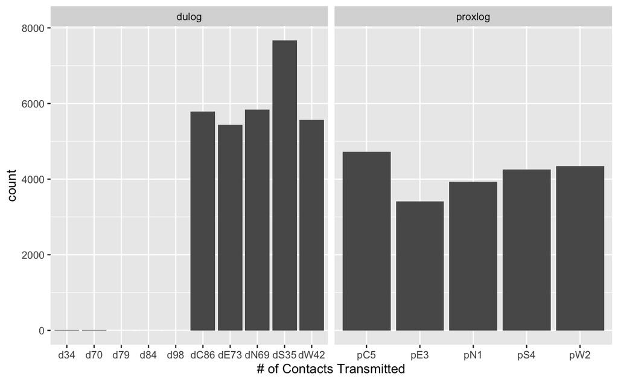

```r
ggplot(Tag_Data, aes(x= TX_Node)) +
      geom_bar() +
      facet_wrap(~tag, scales= "free_x") +
      xlab("# of Contacts Transmitted")
```

```r
#number of meetings received by each tag
Tag_Data %>%
      group_by(tag, RX_Node) %>%
      summarise(n=n())
```

| tag | RX_Node | n |
| --- | --- | --- |
| dulog | dC86 | 7856 |
| dulog | dE73 | 7575 |
| dulog | dN69 | 7164 |
| dulog | dW42 | 7706 |
| proxlog | pC5 | 4700 |
| proxlog | pE3 | 4423 |
| proxlog | pN1 | 2712 |
| proxlog | pS4 | 5236 |
| proxlog | pW2 | 3611 |

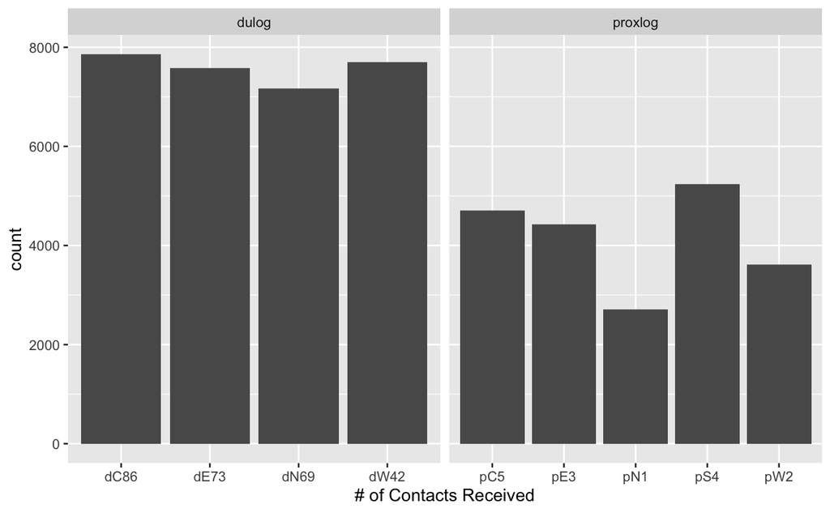

```r
Tag_Data %>%
      group_by(tag) %>%
      ggplot( aes(x= RX_Node)) +
      geom_bar() +
      facet_wrap(~tag, scales="free_x") +
      xlab("# of Contacts Received")
```

A little concerning that some sensors had far more reads than others, but let’s check the read number only for a time when we know all tags should have been in range (10cm), and for a standard unit of time

# add positions (NSEWC)

```r
#number of meetings receieved by each tag for 10 parallel
 #transmitted at 10 parallel
Tag_Data %>%
      filter(test_type == "ten_parallel") %>%
      group_by(tag, RX_Node) %>%
      summarise(n=n())
```

| tag | RX_Node | n |
| --- | --- | --- |
| dulog | dC86 | 1164 |
| dulog | dE73 | 1162 |
| dulog | dN69 | 1163 |
| dulog | dW42 | 1161 |
| proxlog | pC5 | 200 |
| proxlog | pE3 | 896 |
| proxlog | pN1 | 81 |
| proxlog | pS4 | 870 |
| proxlog | pW2 | 234 |

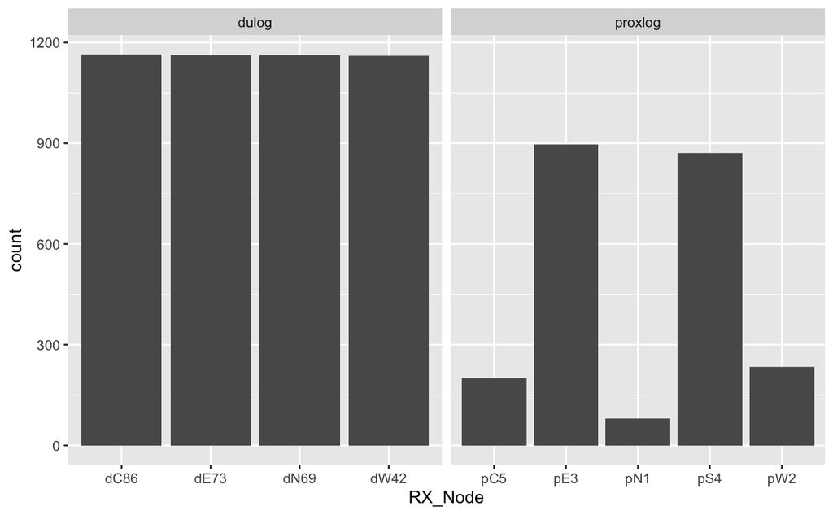

```r
Tag_Data %>%
      filter(test_type == "ten_parallel") %>%
      ggplot( aes(x= RX_Node)) +
      geom_bar() +
      facet_wrap(~tag, scales="free_x")
```

```r
#transmitted at 10 parallel
Tag_Data %>%
      filter(test_type == "ten_parallel") %>%
      group_by(tag, TX_Node) %>%
      summarise(n=n())
```

| tag | TX_Node | n |
| --- | --- | --- |
| dulog | d34 | 1 |
| dulog | d70 | 1 |
| dulog | d84 | 1 |
| dulog | dC86 | 880 |
| dulog | dE73 | 872 |
| dulog | dN69 | 863 |
| dulog | dS35 | 1181 |
| dulog | dW42 | 851 |
| proxlog | pC5 | 538 |
| proxlog | pE3 | 391 |

[output cut: 3 more lines]

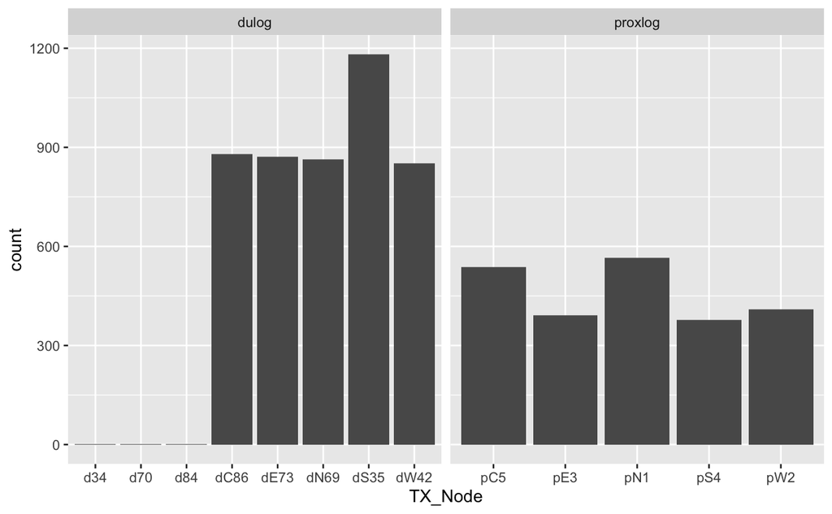

```r
Tag_Data %>%
      filter(test_type == "ten_parallel") %>%
      ggplot( aes(x= TX_Node)) +
      geom_bar() +
      facet_wrap(~tag, scales="free_x")
```

At known ranges, dulog had much more even receiving read rates than proxlogs, which are *really* variable Neither of the tags did a great job at transmitting even # of meetings when the tags were all well within range (one of the dulog tags transmitted a bunch more than the others, the proxlogs are all over the map)

Get rid of weird values, order test_type

```r
# only data from real tags (presumably Dyads with more than 10 readings)

Tag_Data <- Tag_Data %>%
      group_by(Dyad) %>% #get rid of weird made-up tag values
      filter(n() > 10) %>% #get rid of weird made-up tag values (fewer than 10 observations)
       mutate( test_type_tag = paste(test_type, tag, sep = "_")) %>%
      ungroup() %>% #now order test type
       mutate(test_type_tag= fct_relevel(test_type_tag,  c("ten_parallel_dulog", "ten_parallel_proxlog", "ten_moved_dulog", "ten_moved_proxlog", "fifty_parallel_dulog", "fifty_parallel_proxlog", "fifty_moved_dulog", "fifty_moved_proxlog", "hundred_parallel_dulog", "hundred_parallel_proxlog", "hundred_moved_dulog", "hundred_moved_proxlog", "twohundred_parallel_dulog", "twohundred_parallel_proxlog", "threehundred_parallel_dulog","threehundred_parallel_proxlog", "fourhundred_parallel_dulog", "fourhundred_parallel_proxlog", "fivehundred_parallel_dulog", "fivehundred_parallel_proxlog", "sixhundred_parallel_dulog"  )))
```

reads from all meetings, by trial type

[figure not shown]

```r
#number of meetings faceted by test_type

 Tag_Data %>%
 ggplot( aes(x= TX_Node)) +
      geom_bar() +
      facet_wrap(~test_type_tag, scales="free_x", ncol = 2)
```

[figure not shown]

```r
 Tag_Data %>%
 ggplot( aes(x= RX_Node)) +
      geom_bar() +
      facet_wrap(~test_type_tag, scales="free_x", ncol = 2)
```

```r
NA
NA
NA
```

Signal Strength (RSSI) by Distance

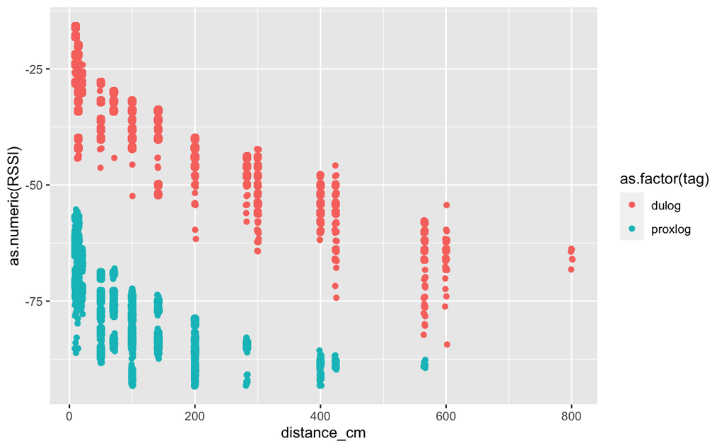

```r
Tag_Data$RSSI <- as.numeric(Tag_Data$RSSI)


# by tag
ggplot(data= Tag_Data, aes(y=as.numeric(RSSI), x= distance_cm, color= as.factor(tag))) +
      geom_point(position = "jitter")
```

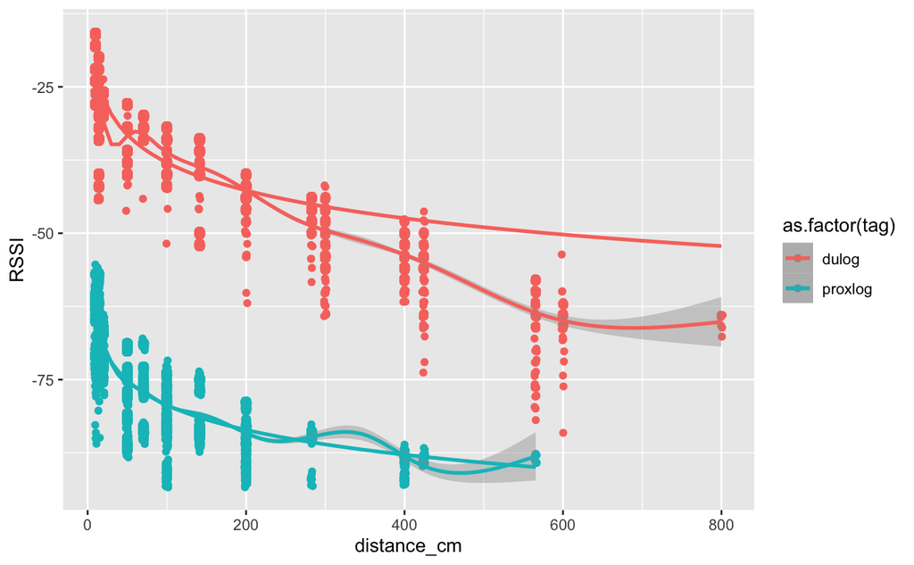

```r
# by tag with trendline
ggplot(data= Tag_Data, aes(y=RSSI, x= distance_cm, color= as.factor(tag))) +
      #geom_point(position = "jitter") +
      geom_jitter() +
       geom_smooth( level = .99) +
      geom_smooth(method = "glm", formula = y~log(x), family = gaussian(link = 'log'))
```

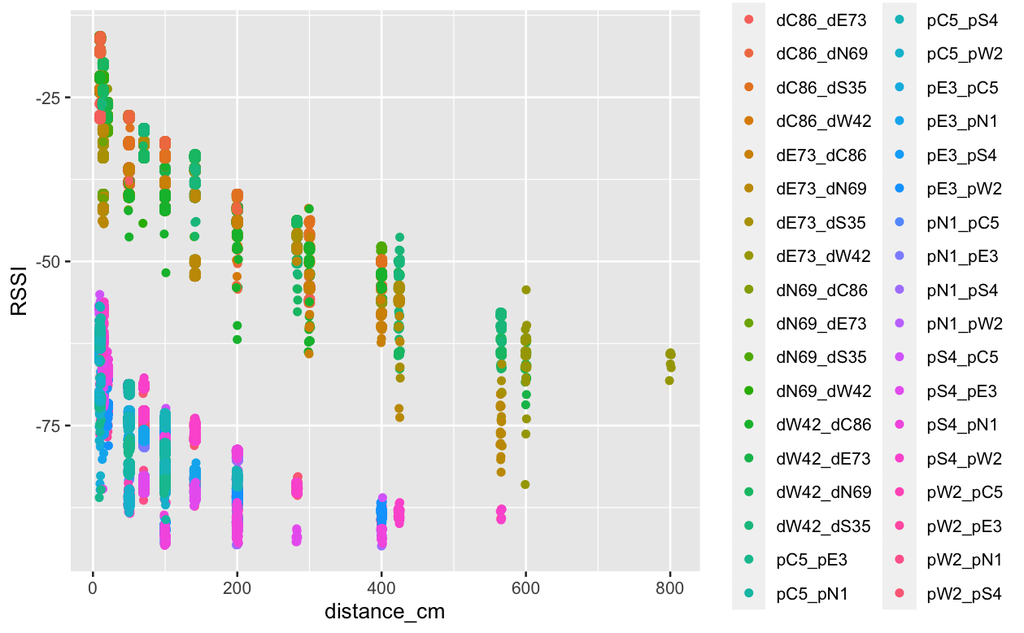

```r
#by RX ID
ggplot(data= Tag_Data, aes(y=RSSI, x= distance_cm, color= RX_TX)) +
      geom_jitter()
```

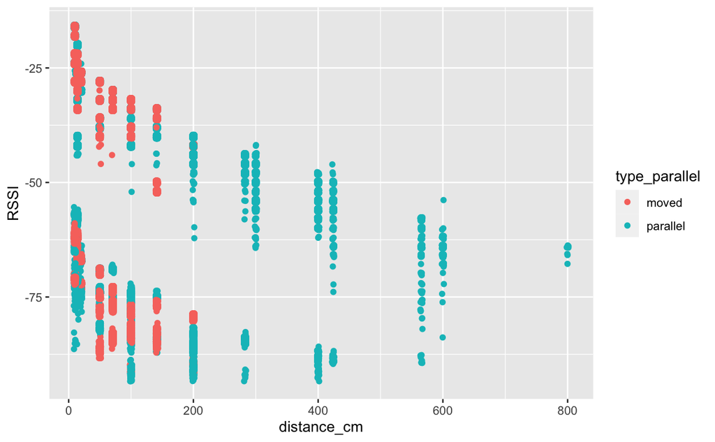

```r
# by tag orientation
Tag_Data %>%
      group_by(distance_cm) %>%
      ggplot( aes(y=RSSI, x= distance_cm, color= type_parallel)) +
      geom_jitter()
```

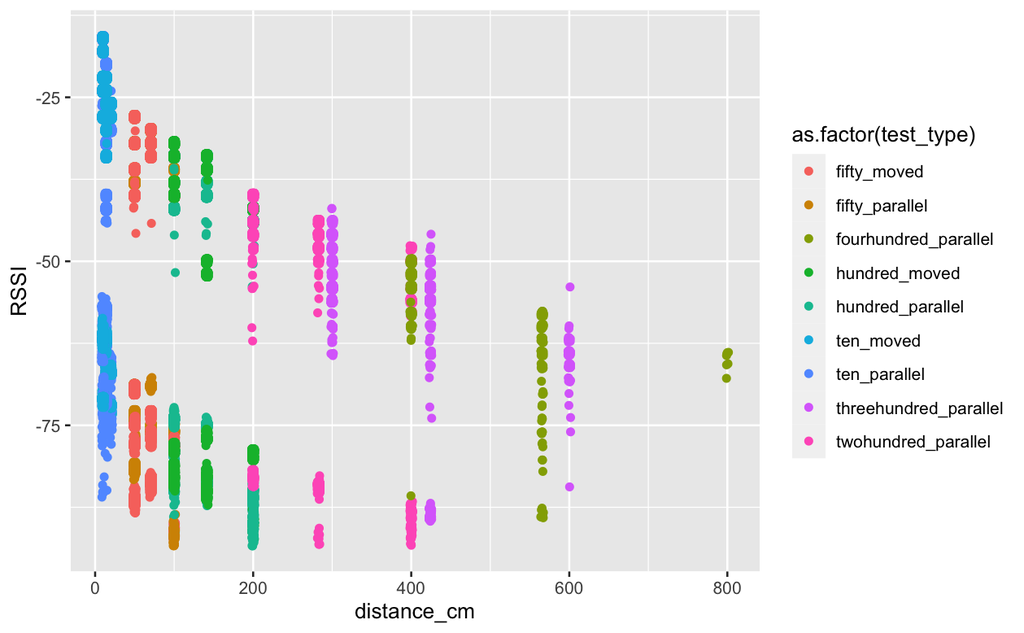

```r
#by test
Tag_Data %>%
      filter(test_type != "group_no") %>%
      group_by(distance_cm) %>%
      ggplot( aes(y=RSSI, x= distance_cm, color= as.factor(test_type))) +
      geom_jitter()
```

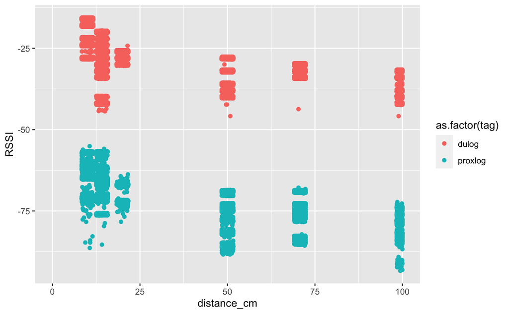

```r
# zooming in on close distances only
# by RX ID
ggplot(data= Tag_Data, aes(y=RSSI, x= distance_cm, color= as.factor(tag))) +
      geom_jitter() +
      xlim(0, 100)
```

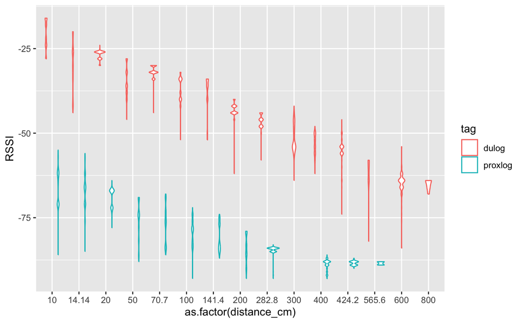

```r
# # trying to summarize distance
Tag_Data %>%
      group_by(tag, distance_cm) %>%
      mutate(dist_test = paste(distance_cm, test_type, sep = "_")) %>%
ggplot(aes(y=RSSI, x= as.factor(distance_cm), color= tag)) +
      geom_violin()
```

```r
str(Tag_Data)
```

```
tibble [50,975 × 13] (S3: tbl_df/tbl/data.frame)
 $ RX_Node       : Ord.factor w/ 9 levels "dC86"<"dE73"<..: 1 1 1 1 1 1 1 1 1 1 ...
 $ TX_Node       : Ord.factor w/ 20 levels "d24"<"d34"<"d48"<..: 14 15 12 13 14 15 12 13 14 15 ...
 $ Date_Time     : POSIXct[1:50975], format: "2023-11-10 12:29:00" "2023-11-10 12:29:00" "2023-11-10 12:29:00" ...
 $ RSSI          : num [1:50975] -16 -16 -24 -18 -16 -16 -24 -18 -16 -16 ...
 $ tag           : chr [1:50975] "dulog" "dulog" "dulog" "dulog" ...
 $ RX_TX         : chr [1:50975] "dC86_dS35" "dC86_dW42" "dC86_dE73" "dC86_dN69" ...
 $ Dyad          : chr [1:50975] "dC86_dS35" "dC86_dW42" "dC86_dE73" "dC86_dN69" ...
 $ test_type     : chr [1:50975] "ten_parallel" "ten_parallel" "ten_parallel" "ten_parallel" ...
 $ Dyad_test_type: chr [1:50975] "dC86_dS35_ten_parallel" "dC86_dW42_ten_parallel" "dC86_dE73_ten_parallel" "dC86_dN69_ten_parallel" ...
 $ distance_cm   : num [1:50975] 10 10 10 10 10 10 10 10 10 10 ...
 $ test          : chr [1:50975] "ten" "ten" "ten" "ten" ...
 $ type_parallel : chr [1:50975] "parallel" "parallel" "parallel" "parallel" ...
 $ test_type_tag : Factor w/ 18 levels "ten_parallel_dulog",..: 1 1 1 1 1 1 1 1 1 1 ...
```

Proxlog and Dulog use different signals, so they have different signal strengths at the same distances. Proxlog declines logarithmically, is especially steep at low distances. Dulog initially declines very precipitously and later declines linearly.

Differences in signal strength variance by group

```r
sd_tags <- Tag_Data %>%
      filter(distance_cm < 600 ) %>%
  group_by( distance_cm, tag) %>%
      summarize(RSSI_SD=sd(RSSI), RSSI_mean = mean(RSSI), N=n())
sd_tags
```

| distance_cm | tag | RSSI_SD | RSSI_mean | N |
| --- | --- | --- | --- | --- |
| 10.00 | dulog | 4.2815305 | -20.62762 | 4012 |
| 10.00 | proxlog | 5.0003980 | -65.72308 | 2405 |
| 14.14 | dulog | 6.8558497 | -29.17335 | 3392 |
| 14.14 | proxlog | 4.6358569 | -66.94156 | 2310 |
| 20.00 | dulog | 1.2965775 | -26.86741 | 1697 |
| 20.00 | proxlog | 2.6124893 | -68.90395 | 1166 |
| 50.00 | dulog | 4.1785559 | -34.35618 | 4071 |
| 50.00 | proxlog | 5.4343828 | -75.63636 | 3718 |
| 70.70 | dulog | 1.3875631 | -31.66724 | 3492 |
| 70.70 | proxlog | 5.4605915 | -76.97442 | 2737 |

[output cut: 15 more lines]

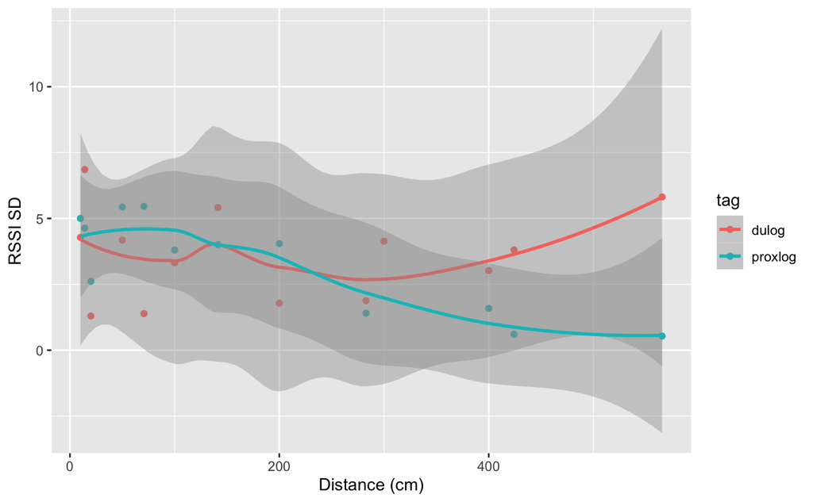

```r
sd_tags %>%
      ggplot(aes(x=distance_cm, y= RSSI_SD, color = tag )) +
      geom_point() +
      geom_smooth(level = .99) +
      xlab("Distance (cm)") +
      ylab("RSSI SD")
```

```r
 Tag_Data %>%
       group_by(distance_cm) %>%
       filter(any(tag=="dulog") & any(tag=="proxlog")) %>% #remove groups where there aren't observations for both prox and dulogs.
       group_by(distance_cm) %>%
       group_map(~ bartlett.test(x=.$RSSI, g=.$tag))
```

```
[[1]]

    Bartlett test of homogeneity of variances

data:  .$RSSI and .$tag
Bartlett's K-squared = 74.031, df = 1, p-value < 2.2e-16


[[2]]

    Bartlett test of homogeneity of variances

data:  .$RSSI and .$tag
Bartlett's K-squared = 391.6, df = 1, p-value < 2.2e-16


[[3]]

    Bartlett test of homogeneity of variances

data:  .$RSSI and .$tag
Bartlett's K-squared = 682.36, df = 1, p-value < 2.2e-16


[[4]]

    Bartlett test of homogeneity of variances

data:  .$RSSI and .$tag
Bartlett's K-squared = 267.33, df = 1, p-value < 2.2e-16


[[5]]

    Bartlett test of homogeneity of variances

data:  .$RSSI and .$tag
Bartlett's K-squared = 4936.5, df = 1, p-value < 2.2e-16


```

[output cut: 39 more lines]

```

[[11]]

    Bartlett test of homogeneity of variances

data:  .$RSSI and .$tag
Bartlett's K-squared = 138.35, df = 1, p-value < 2.2e-16


[[12]]

    Bartlett test of homogeneity of variances

data:  .$RSSI and .$tag
Bartlett's K-squared = 25.105, df = 1, p-value = 5.428e-07
```

```r
       #bartlett.test(x=.$RSSI, g=.$tag)

  #bartlett.test(RSSI ~ tag)
#find the mean difference in signal strength between each group
#compare the variance between each group @ given signal strength  Bartlett test


Tag_Data %>%
      filter(distance_cm ==100.00) %>%
      group_by(test_type, tag) %>%
  filter(row_number()==1)
```

| RX_Node | TX_Node | Date_Time | RSSI | tag | RX_TX | Dyad | test_type | Dyad_test_type | distance_cm | test | type_parallel | test_type_tag |
| --- | --- | --- | --- | --- | --- | --- | --- | --- | --- | --- | --- | --- |
| dN69 | dS35 | 2023-11-10 12:54:00 | -34 | dulog | dN69_dS35 | dN69_dS35 | fifty_parallel | dN69_dS35_fifty_parallel | 100 | fifty | parallel | fifty_parallel_dulog |
| dN69 | dS35 | 2023-11-10 13:06:00 | -34 | dulog | dN69_dS35 | dN69_dS35 | fifty_moved | dN69_dS35_fifty_moved | 100 | fifty | moved | fifty_moved_dulog |
| dN69 | dC86 | 2023-11-10 13:18:00 | -34 | dulog | dN69_dC86 | dC86_dN69 | hundred_parallel | dC86_dN69_hundred_parallel | 100 | hundred | parallel | hundred_parallel_dulog |
| dN69 | dC86 | 2023-11-10 13:30:00 | -32 | dulog | dN69_dC86 | dC86_dN69 | hundred_moved | dC86_dN69_hundred_moved | 100 | hundred | moved | hundred_moved_dulog |
| pN1 | pS4 | 2023-11-10 17:06:24 | -92 | proxlog | pN1_pS4 | pN1_pS4 | fifty_parallel | pN1_pS4_fifty_parallel | 100 | fifty | parallel | fifty_parallel_proxlog |
| pN1 | pS4 | 2023-11-10 17:15:02 | -78 | proxlog | pN1_pS4 | pN1_pS4 | fifty_moved | pN1_pS4_fifty_moved | 100 | fifty | moved | fifty_moved_proxlog |
| pN1 | pC5 | 2023-11-10 17:30:49 | -89 | proxlog | pN1_pC5 | pC5_pN1 | hundred_parallel | pC5_pN1_hundred_parallel | 100 | hundred | parallel | hundred_parallel_proxlog |
| pN1 | pC5 | 2023-11-10 17:39:00 | -79 | proxlog | pN1_pC5 | pC5_pN1 | hundred_moved | pC5_pN1_hundred_moved | 100 | hundred | moved | hundred_moved_proxlog |

Sensitivity to tag direction

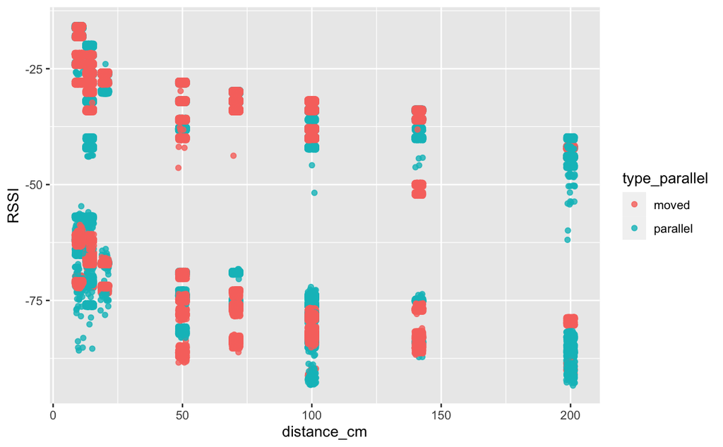

```r
# by tag orientation
Tag_Data %>%
      group_by(distance_cm) %>%
      filter(distance_cm <= 200) %>%
      ggplot( aes(y=RSSI, x= distance_cm, color= type_parallel)) +
      geom_jitter(alpha = .8)
```

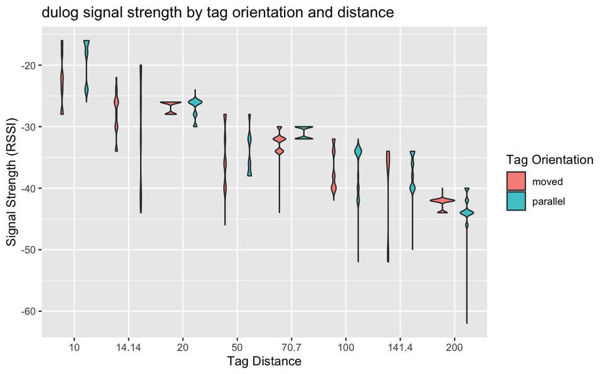

```r
#dulog comparison
Tag_orientation_p <- function(Tag) {
      Tag_Data %>%
       filter(distance_cm <= 200) %>%
      filter(tag== Tag) %>%
      group_by(distance_cm, type_parallel) %>%
      mutate(dist_pos = paste(distance_cm, type_parallel, sep = "_")) %>%
      mutate(dist_pos = fct_reorder(dist_pos, distance_cm)) %>%
      ggplot( aes(y=RSSI, x= as.factor(distance_cm), fill= type_parallel)) +
      geom_violin(alpha = .8) +
      xlab("Tag Distance") +
      ylab("Signal Strength (RSSI)") +
      scale_fill_discrete(name = "Tag Orientation") +
      ggtitle(paste(Tag, "signal strength by tag orientation and distance", sep = " "))

}

Tag_orientation_p(Tag = "dulog")
```

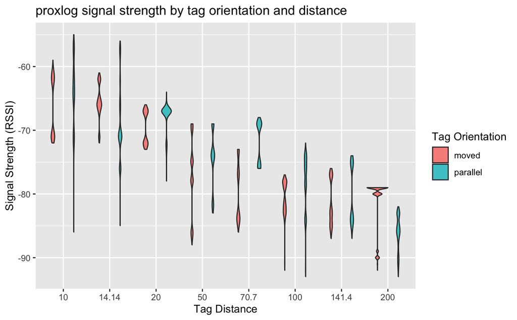

```r
Tag_orientation_p(Tag = "proxlog")
```

```r
#summarize differences between groups at each point (not adjusted for multiple comparisons)
Tag_Data %>%
      filter(distance_cm <= 200) %>%
      group_by(distance_cm, tag) %>%
      summarize(T_test = t.test(RSSI[type_parallel=="parallel"], RSSI[type_parallel=="moved"])$p.value)
```

| distance_cm | tag | T_test |
| --- | --- | --- |
| 10.00 | dulog | 3.678615e-188 |
| 10.00 | proxlog | 2.561334e-20 |
| 14.14 | dulog | 5.387324e-23 |
| 14.14 | proxlog | 1.235605e-51 |
| 20.00 | dulog | 8.387294e-07 |
| 20.00 | proxlog | 1.993484e-34 |
| 50.00 | dulog | 4.841175e-01 |
| 50.00 | proxlog | 4.095472e-51 |
| 70.70 | dulog | 3.972904e-196 |
| 70.70 | proxlog | 0.000000e+00 |

[output cut: 6 more lines]

```r
rice[color=="E"]
```

[output not shown]

The orientation of the tag does not seem to have a consistent effect for either tag, though the positions in this test were not highly standard.